# HW 1, Sejal Jagtap, ssj40

```r
library(readr)
library(dplyr)
library(tidyr)
library(stringr)
library(tidytext)
library(ggplot2)
library(forcats)
library(tibble)
library(scales)
```

```r
# Check current working directory
getwd()
```

```
[1] "/Users/sejal/Documents/Text_As_Data/text_as_data"
```

```r
# Check if files are present in texts/
list.files("texts")
```

```
[1] "A07594__Circle_of_Commerce.txt" "B14801__Free_Trade.txt"
```

```r
# Read the two files from local directory texts/:
file_a <- "texts/A07594__Circle_of_Commerce.txt"
file_b <- "texts/B14801__Free_Trade.txt"

# Read the raw text files into R
text_a <- read_file(file_a)
text_b <- read_file(file_b)

# Combine into a tibble for tidytext workflows
texts <- tibble(
  doc_title = c("Text A", "Text B"),
  text = c(text_a, text_b)
)

texts
```

| doc_title | text |
| --- | --- |
| Text A | THE CIRCLE OF COMMERCE. The Prooeme. HERODOTVS in his CLIO, reportes that CROESVS King of LYDIA had a ſonne borne dumbe: and his Countrey being invaded, and the King himſelf in imminent danger of deat… |
| Text B | CAP. I. The Causes of the want of Money in England. IT hauing pleased God to giue mee my Birth and Being in this Good Land, and vnder the Reigne of so Great a KING; whose Peace and Piety, whose Pruden… |

```r
#Confirm if text is loaded
cat(substr(text_a, 1, 500))
```

```
THE CIRCLE OF COMMERCE. The Prooeme. HERODOTVS in his CLIO, reportes that CROESVS King of LYDIA had a ſonne borne dumbe: and his Countrey being invaded, and the King himſelf in imminent danger of death by a certaine Perſian ready to lay violent hands on him; the Kings ſonne affected with the preſent…
```

I. Create a diagnostics table (before stopword removal)

1. texts: tibble where each row corresponds to a document.
2. mutate(n_chars = str_length(text)): computes the number of characters in each doc, adds a new column n_chars
3. unnest_tokens(word, text): breaks each document’s text into individual word tokens. Converts data from one row per document to one row per word token. Tokenized words are stored in a new column ‘word’.
4. mutate(word = str_to_lower(word)) :converts to lower case
5. group_by(doc_title) :groups all word tokens back by their original document.
6. summarise :multiple rows per document are collapsed back into one row per document.
7. n_chars = first(n_chars): nchars is repeated for every word in the document.first(n_chars) safely keeps the original document-level value.
8. n_word_tokens = n(): Count the total number of word tokens in each document.(before stopword removal)
9. n_word_types = n_distinct(word): Count the number of unique word types in each document. 10..groups = “drop”: Ungroup the result so the final tibble is not grouped.

```r
corpus_diagnostics <- texts %>%
  mutate(n_chars = str_length(text)) %>%
  unnest_tokens(word, text) %>%
  mutate(word = str_to_lower(word)) %>%
  group_by(doc_title) %>%
  summarise(
    n_chars = first(n_chars),
    n_word_tokens = n(),
    n_word_types = n_distinct(word),
    .groups = "drop"
  )

corpus_diagnostics
```

| doc_title | n_chars | n_word_tokens | n_word_types |
| --- | --- | --- | --- |
| Text A | 191605 | 33889 | 4773 |
| Text B | 114211 | 19922 | 3332 |

II.Interpret the diagnostics

1. Are Text A and Text B comparable in length?

As per above observation, Text A contains 191,605 characters and 33,889 word tokens, while Text B contains 114,211 characters and 19,922 word tokens, making Text A longer than Text B by both measures. To conclude, they are not directly comparable in length.

2. If they differ substantially, what does that imply for interpreting raw frequency comparisons?

The raw word frequency would favor Text A, due to its greater volume of text rather than actual differences in use of language. A direct comparison between texts would therefore be misleading and inaccurate.

```r
# Start with tidytext's built-in stopword list
data("stop_words")

# Add our own project-specific stopwords (you can, and will, expand this list later)
custom_stopwords <- tibble(
  word = c(
    "vnto", "haue", "doo", "hath", "bee", "ye", "thee"
  )
)

all_stopwords <- bind_rows(stop_words, custom_stopwords) %>%
  distinct(word)

all_stopwords %>% slice(1:10)
```

| word |
| --- |
| a |
| a's |
| able |
| about |
| above |
| according |
| accordingly |
| across |
| actually |
| after |

```r
word_counts <- texts %>%
  unnest_tokens(word, text) %>%
  mutate(word = str_to_lower(word)) %>%
  anti_join(all_stopwords, by = "word") %>%
  count(doc_title, word, sort = TRUE)

word_counts
```

| doc_title | word | n |
| --- | --- | --- |
| Text A | trade | 232 |
| Text A | exchange | 186 |
| Text B | trade | 185 |
| Text A | ſo | 184 |
| Text A | malynes | 158 |
| Text A | merchants | 126 |
| Text A | mony | 118 |
| Text A | hee | 115 |
| Text A | kingdome | 113 |
| Text A | commodities | 96 |

[output cut: 990 more lines]

```r
doc_lengths <- word_counts %>%
  group_by(doc_title) %>%
  summarise(
    total_words = sum(n),
    .groups = "drop"
  )
```

```r
word_counts_normalized <- word_counts %>%
  left_join(doc_lengths, by = "doc_title") %>%
  mutate(relative_freq = n / total_words)
```

```r
# Compare trade in both texts
trade_comparison <- word_counts_normalized %>%
  filter(word == "trade") %>%
  select(doc_title, n, total_words, relative_freq)

trade_comparison
```

| doc_title | n | total_words | relative_freq |
| --- | --- | --- | --- |
| Text A | 232 | 14694 | 0.01578876 |
| Text B | 185 | 8004 | 0.02311344 |

```r
NA
```

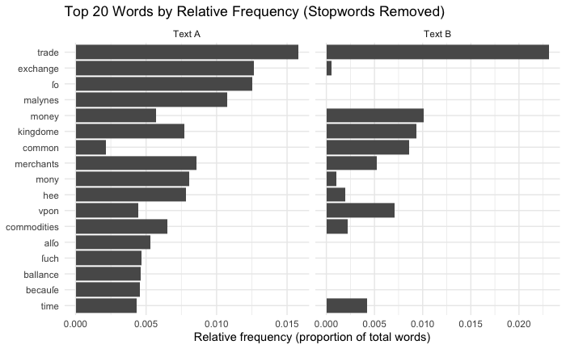

```r
plot_n_words <- 20

word_comparison_tbl_norm <- word_counts_normalized %>%
  pivot_wider(
    names_from = doc_title,
    values_from = n,
    values_fill = 0
  ) %>%
  mutate(max_n = pmax(`Text A`, `Text B`)) %>%
  arrange(desc(max_n))

top_words <- word_comparison_tbl_norm %>%
  slice_head(n = plot_n_words) %>%
  select(word)

word_plot_data_norm <- word_counts_normalized %>%
  semi_join(top_words, by = "word") %>%
  mutate(word = fct_reorder(word, relative_freq, .fun = max))


ggplot(word_plot_data_norm, aes(x = relative_freq, y = word)) +
  geom_col() +
  facet_wrap(~ doc_title, scales = "free_x") +
  labs(
    title = "Top 20 Words by Relative Frequency (Stopwords Removed)",
    x = "Relative frequency (proportion of total words)",
    y = NULL
  ) +
  theme_minimal()
```